# Vasicek Model for Interest Rates

##### Reference: https://en.wikipedia.org/wiki/Vasicek_model (1977)

### Multidimensional Stochastic Processes

```python
import numpy as np
import numpy.random as npr
import matplotlib.pyplot as plt
import pandas as pd
import math
```

Do also:

- Hull–White model
- CIR model
- Merton (Ho-Lee) model, Black-Karasinski (Black-Derman-Toy)

It is a mathematical model describing the evolution of interest rates. It is a one-factor short rate model, interest rate movements are driven by only one source of market risk. The model can be used in the valuation of interest rate derivatives.

It is basically an AR(1) process, GBM is modified to introduce mean reversion. Interest rates exist in a limited range.

SDE:

$dr_t = a(b - r_t)dt + \sigma\sqrt{dt} z_t $

Terminal value asymptotic distribution is $ N(b, \sigma^2/(2a))$.

b = long-term mean

a = speed of reversion

$\sigma^2/(2a) $ = long-term volatility

We do not need to impose that $r_t$ be positive values.

There is an application to European short-term interest rates below.

```python
#Simulate I paths:
T = 500
I = 100
dt = 1/50

#What are plausible parameter values?
sigma = 0.05
r0 = 0.1
a = 2.0
b= 0.05
theta = [a,b,sigma]

def Vasicek(theta):
    r = np.zeros((T+1, I))
    r[0, :] = r0

    for t in range(1, T+1):
        z=npr.standard_normal(I)
        r[t, :]=r[t-1,:] +theta[0]*(theta[1]-r[t-1,:])*dt+theta[2]*np.sqrt(dt)*z
    return r

r = Vasicek(theta)
```

```python
LTStd = sigma/math.sqrt(2*a); LTStd
```

```
0.025
```

```python
df = pd.DataFrame(r)
df.describe()
# Google total re
```

|  | 0 | 1 | 2 | 3 | 4 | 5 | 6 | 7 | 8 | 9 | ... | 90 | 91 | 92 | 93 | 94 | 95 | 96 | 97 | 98 | 99 |
| --- | --- | --- | --- | --- | --- | --- | --- | --- | --- | --- | --- | --- | --- | --- | --- | --- | --- | --- | --- | --- | --- |
| count | 501.000000 | 501.000000 | 501.000000 | 501.000000 | 501.000000 | 501.000000 | 501.000000 | 501.000000 | 501.000000 | 501.000000 | ... | 501.000000 | 501.000000 | 501.000000 | 501.000000 | 501.000000 | 501.000000 | 501.000000 | 501.000000 | 501.000000 | 501.000000 |
| mean | 0.059204 | 0.054405 | 0.051587 | 0.047544 | 0.050570 | 0.054908 | 0.037890 | 0.055462 | 0.055035 | 0.056309 | ... | 0.046472 | 0.044013 | 0.056133 | 0.047333 | 0.065450 | 0.058638 | 0.054307 | 0.057164 | 0.056380 | 0.067504 |
| std | 0.019852 | 0.024084 | 0.022124 | 0.022873 | 0.027052 | 0.024540 | 0.025908 | 0.023603 | 0.027678 | 0.026316 | ... | 0.032923 | 0.022456 | 0.020498 | 0.024077 | 0.020605 | 0.032983 | 0.023667 | 0.017914 | 0.023256 | 0.025123 |
| min | 0.000888 | -0.004094 | -0.015962 | -0.005261 | -0.019419 | 0.002830 | -0.025742 | 0.002684 | -0.027665 | -0.001042 | ... | -0.022755 | -0.005974 | -0.000160 | -0.029049 | 0.021355 | -0.023941 | 0.001382 | 0.003884 | -0.002807 | 0.003058 |
| 25% | 0.045800 | 0.038191 | 0.034475 | 0.030246 | 0.031330 | 0.036914 | 0.018555 | 0.040508 | 0.036093 | 0.036223 | ... | 0.020800 | 0.027683 | 0.043369 | 0.035306 | 0.050765 | 0.035458 | 0.036575 | 0.044896 | 0.037637 | 0.051428 |
| 50% | 0.057479 | 0.053558 | 0.054008 | 0.044126 | 0.053603 | 0.051413 | 0.033922 | 0.052219 | 0.054166 | 0.052734 | ... | 0.045622 | 0.042219 | 0.057408 | 0.049285 | 0.064577 | 0.061600 | 0.055739 | 0.056636 | 0.058870 | 0.069294 |
| 75% | 0.072240 | 0.068289 | 0.067567 | 0.064948 | 0.067051 | 0.068173 | 0.056600 | 0.070473 | 0.076379 | 0.074553 | ... | 0.070734 | 0.058411 | 0.070588 | 0.060916 | 0.077397 | 0.085859 | 0.070212 | 0.069149 | 0.073330 | 0.083729 |
| max | 0.120733 | 0.120920 | 0.106779 | 0.100000 | 0.105701 | 0.131934 | 0.101044 | 0.120201 | 0.118075 | 0.131398 | ... | 0.122284 | 0.114923 | 0.104723 | 0.109325 | 0.126098 | 0.121032 | 0.115072 | 0.113119 | 0.118506 | 0.133691 |

8 rows × 100 columns

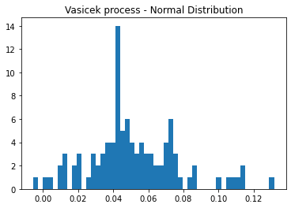

```python
rT = r[-1]

fig, ax1 = plt.subplots()#
ax1.hist(rT, bins=50); ax1.set_title('Vasicek process - Normal Distribution')
```

```python
df = pd.DataFrame(rT)
df.describe()
```

|  | 0 |
| --- | --- |
| count | 100.000000 |
| mean | 0.051208 |
| std | 0.025854 |
| min | -0.005500 |
| 25% | 0.037485 |
| 50% | 0.047219 |
| 75% | 0.067146 |
| max | 0.131666 |

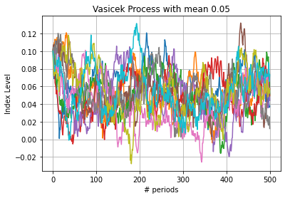

```python
plt.plot(r[:, :10], lw = 1.5)
plt.xlabel('# periods'); plt.ylabel('Index Level'); plt.title("Vasicek Process with mean 0.05")
plt.grid(True)
```

```python
#Autocorrelation is very high among state variables and dies out very slowly.
np.corrcoef(r[:-1,0], r[1:,0])
```

```
array([[1.        , 0.93207337],
       [0.93207337, 1.        ]])
```

```python
#Correlation should be negative between state variables and subsequent return, and proportional with a and rt.
dr = r[1:,0]/r[:-1,0]-1
dr.shape
np.corrcoef(r[:-1,0], dr) #?
```

```
array([[ 1.        , -0.18279462],
       [-0.18279462,  1.        ]])
```

### Application to Short-Term Interest Rates

Though LIBOR, Euribor, and the federal funds rate are concerned with the same action, i.e. interbank loans, there is an important distinction: the federal funds rate is a target interest rate that is set by the FOMC for implementing U.S. monetary policies.

For this reason I shall use Eonia. The Eonia rate is the 1-day interbank interest rate for the Euro zone. In other words, it is the rate at which banks provide loans to each other with a duration of 1 day. Therefore Eonia can be considered as the 1 day Euribor rate.

As of 1 October 2019 EONIA is calculated with a reformed methodology tracking the euro short-term rate (EONIA: Euro Interbank Offered Rate). Following a recommendation made by the working group on euro risk-free rates on 14 March 2019, as of 2 October for the trade date 1 October 2019 the European Money Market Institute (EMMI) changed the way it calculates the EONIA. Rate for the overnight maturity is calculated as the euro short-term rate plus a spread of 8.5 basis points. Eonia will be discontinued on Jan. 3, 2022.

ESTR Data http://webstat.banque-france.fr/en/quickview.do?SERIES_KEY=285.ESTR.B.EU000A2X2A25.WT

```python
#import csv data
lines = open('./ESTR.csv','r').readlines()
lines = [line.replace("", "") for line in lines]
lines[:4]
```

```
['Date,ESTR\n', '01.10.19,-0.549\n', '02.10.19,-0.551\n', '03.10.19,-0.555\n']
```

```python
#import data from the csv file with read_csv
estr = pd.read_csv('./ESTR.csv', index_col=0, parse_dates=True, sep=",", dayfirst=True,  false_values='0',)
np.round(estr.head())
```

| Date | ESTR |
| --- | --- |
| 2019-10-01 | -1.0 |
| 2019-10-02 | -1.0 |
| 2019-10-03 | -1.0 |
| 2019-10-04 | -1.0 |
| 2019-10-07 | -1.0 |

```python
nulls = estr[ estr['ESTR'] == '-' ].index
# Delete these row indexes from dataFrame
estr.drop(nulls , inplace=True)
```

```python
estr.sort_index(axis = 0)
estr['ESTR'] = estr['ESTR'].astype(float) #for some reason the data appeared as strings
```

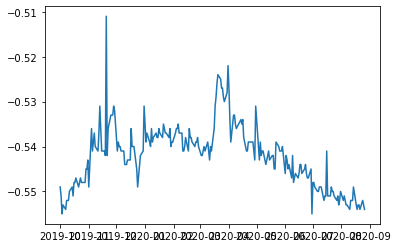

```python
plt.plot(estr['ESTR'])
```

```python
estr.describe()
```

|  | ESTR |
| --- | --- |
| count | 231.000000 |
| mean | -0.542087 |
| std | 0.007155 |
| min | -0.555000 |
| 25% | -0.548000 |
| 50% | -0.541000 |
| 75% | -0.538000 |
| max | -0.511000 |

```python
es = np.array(estr['ESTR'])
des = es[1:]/es[:-1]-1 #% change in short term rates
```

```python
np.corrcoef(des,es[:-1])
#First-order autocorrelation is positive!
```

```
array([[1.        , 0.30008802],
       [0.30008802, 1.        ]])
```

```python
#Bird's Eye View Calibration:
#Long-term mean:
b = np.mean(es)
#Long-term standard deviation is a function of a and sigma:
#LTstd = np.std(es)
#We can use the autocorrelation to find a:
#beta = -a = cov(rt, drt)/var(rt)
VCV = np.cov(es[:-1], des)
a = -VCV[1,0]/np.var(es)
sigma = np.std(es)*np.sqrt(2*a)

print(round(a,5), round(b,5), round(sigma,5))

#Oops! First-order autocorrelation is positive, so it is not a Vasicek process.
```

```
-0.33843 -0.54209 nan
```

```python
import statsmodels

from statsmodels import tsa
```

```python
#ACF = tsa.stattools.acf(es, nlags=10, fft=False)
#pd.DataFrame(ACF, columns=['ACF'])
```

```python
#PACF = tsa.stattools.pacf(es, nlags=10)
#pd.DataFrame(PACF, columns=['PACF'])
```

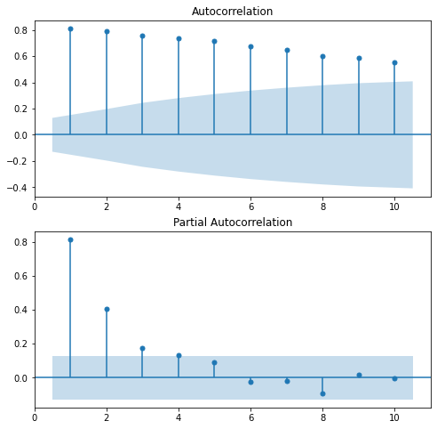

```python
# statsmodels.tsa.stattools.pacf(es, nlags=10)
from statsmodels.graphics.tsaplots import plot_acf, plot_pacf

# Create figure
fig, (ax1, ax2) = plt.subplots(2,1, figsize=(8,8))
# Make ACF plot
plot_acf(es, lags=10, zero=False, ax=ax1)
# Make PACF plot
plot_pacf(es, lags=10, zero=False, ax=ax2)
plt.show()
```

```python
#One example of a Vasicek model with random parameters
T = len(es)-1
I = 1
dt = 1/50
theta = [0, 0.04, 0.2]

r0 = es[0]

r = Vasicek(theta)
```

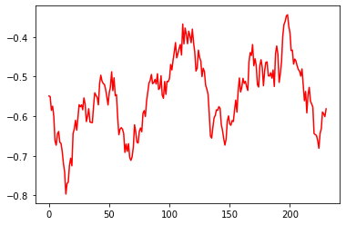

```python
plt.plot(r, 'r')
```

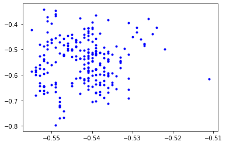

```python
plt.plot(es, r,'b.')
```

```python
#Just for the sake of the exercise, I shall try to fit The Vasicek model parameters using fmin.

ordd = 2
N=10

f = lambda theta: Vasicek(theta) #I minimize the norm for each value of the short-term rate

#g = lambda theta: np.linalg.norm(es-f(theta), ord=ordd)**ordd
def g(theta):
    g=0
    for n in range(0,N):
        g += np.linalg.norm(es-f(theta), ord=ordd)**ordd
    return g
```

```python
import scipy.optimize
thetaopt = scipy.optimize.fmin(func=g, x0=[0.,0.,0.],ftol=1e-7,xtol=1e-7)
print('Parameters a,b,sigma for Euro short-term rate', thetaopt)
```

[output not shown]

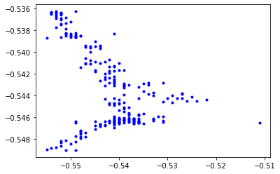

```python
ropt = Vasicek(thetaopt)
plt.plot(es, ropt,'b.')
```

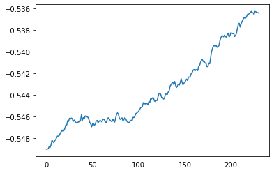

```python
plt.plot(ropt)
```

The results do not appear implausible, in spite of using the wrong model and obtaining weird parameter values like negative speed of reversion to the mean and negative instantaneous standard deviation.

```python
#Normality tests

import scipy as sp
from scipy import stats
```

```python
#Shapiro-Wilk normality test

from scipy.stats import shapiro
stat, p = shapiro(es)
print('Statistics=%.3f, p=%.3f' % (stat, p))
# interpret
alpha = 0.05
if p > alpha:
	print('Sample looks Gaussian (fail to reject H0)')
else:
	print('Sample does not look Gaussian (reject H0)')
```

```
Statistics=0.965, p=0.000
Sample does not look Gaussian (reject H0)
```

```python
#Jarque-Bera normality test

JB, p = stats.jarque_bera(es)
print('Statistics=%.3f, p=%.3f' % (JB, p))
# interpret
alpha = 0.05
if p > alpha:
	print('Sample looks Gaussian (fail to reject H0)')
else:
	print('Sample does not look Gaussian (reject H0)')
```

```
Statistics=16.441, p=0.000
Sample does not look Gaussian (reject H0)
```